# **Investigation of cutting discs (in)efficiency via ANOVA**

Hot rolled steel bars must be cutted in certain customer needed length. Different cutting disc types can be applied for this process. We are going to - by means of **AN**alysisis **O**f **VA**riances - figure out, which of three selected cutting discs have the best efficiency respectively the biggest inefficiency. The **inefficiency** is measured by the **product of price times wear and tear** of **cutting discs**.

The effect of following independent variables / process parameters (x-values) will be investigated on the inefficiency respectively on the product of price times wear and tear (y-value, dependent) of cutting discs:

- Disc type
- Steel bar temperature
- Circumferential speed of cutting machine
- Feed speed of cutting machine
- Carbon content of the steel bars
- Area of the steel bars
- Diameter of the steel bars

# **Get data / Visualize inefficiency of cutting discs**

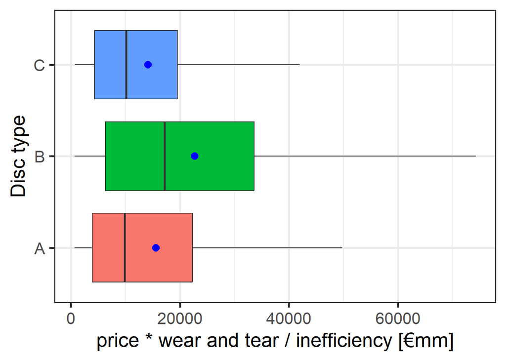

Figure 1: Inefficiency of disc types

```r
# load packages
options(contrasts = c("contr.sum", "contr.poly"))
library(tidyverse)
library(scales)
library(reshape2)
library(car)
library(doParallel)
library(foreach)

# Load data set
data.cut <- readRDS("data.cut.rds")

# Plot data to see what kind of data we have
data.cut %>%
  ggplot(aes(disc.type, inefficiency, fill = disc.type)) +
  geom_boxplot(outliers = F)  +
  theme_bw(base_size = 20) +
  xlab("Disc type") +
  scale_y_continuous("price * wear and tear / inefficiency [€mm]", breaks = pretty_breaks(n = 5)) +
  stat_summary(fun.y = mean, geom = "point", shape = 20, size = 5, color = "blue", position = position_dodge(0.75), show.legend = F) +
  coord_flip() +
  theme(
    legend.position = "none"
  )
```

Disc B seems to have the biggest inefficiency. The question is now: **Is this result significant?** For this purpose first of all, we will look at confidence intervals.

# **Confidence interval**

In Figure 2 you can see the mean values of product of price times wear and tear and the corresponding confidence intervals (95%) for the three disc types. There are no overlaps between the confidence intervals of inefficiencies (y-value) of disc types; it seems that the disc types differs (significantly) each other. We will proof that later via ANOVA!

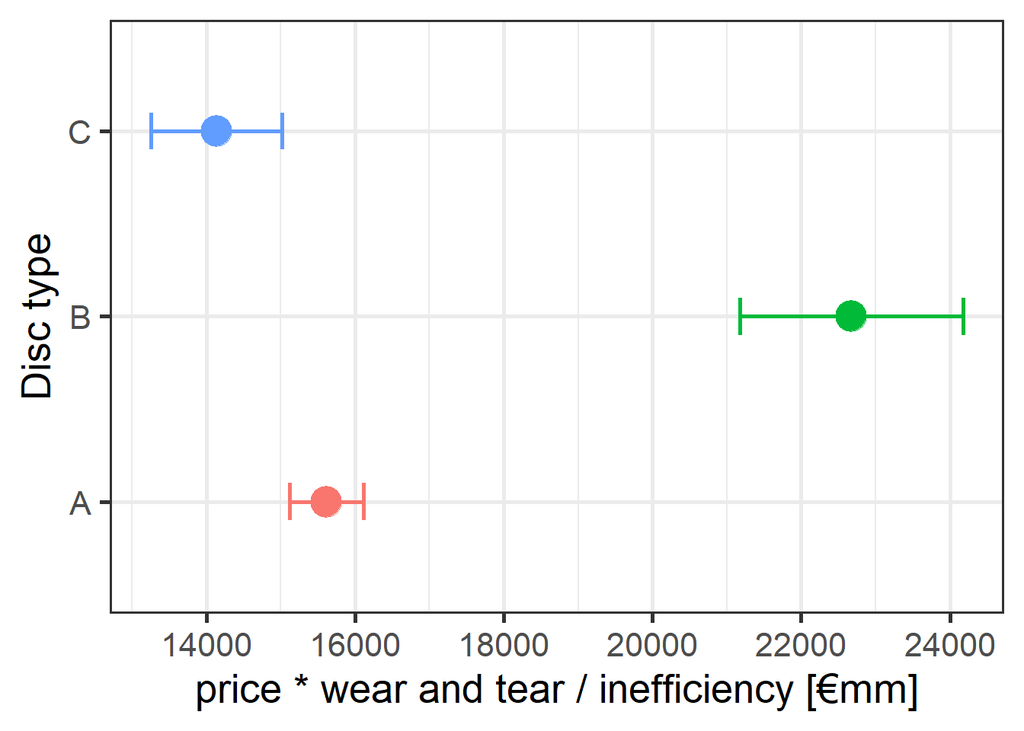

Figure 2: Confidence interval (95%) of inefficiency for different disc types

```r
# Calculate confidence interval
library(Rmisc)
data.cut.confidence <-
  data.cut %>%
  group_by(disc.type) %>%
  dplyr::summarise(avg_inefficiency = mean(inefficiency),
                   uci_inefficiency = CI(inefficiency)[1],
                   lci_inefficiency = CI(inefficiency)[3])

# Plot confidence interval
ggplot(data = data.cut.confidence, aes(x = disc.type, y = avg_inefficiency, color = disc.type)) +
  geom_point(size = 7) +
  geom_errorbar(aes(ymin=uci_inefficiency, ymax=lci_inefficiency), size = 1, width=.2, position=position_dodge(0.05)) +
  xlab("Disc type") + ylab("price * wear and tear / inefficiency [€mm]") +
  scale_y_continuous(breaks = pretty_breaks(n = 5)) +
  theme_bw(base_size = 20) +
  coord_flip() +
  theme(
    legend.position = "none"
    )
```

# **Convert continuous data to categorical data**

ANOVA needs continuous dependent variable and categorical independent variables. We will divide all (continuous) independent variables into four categories (quartile).

```r
# Calculate quartile for bar area
q.bar.area <- quantile(data.cut$area)
# Create new column for the different (four) categories of bar area
data.cut$area.factor <- cut(data.cut$area, c(-Inf, 1982.594, 4190.840, 8557.842, Inf),
                           labels = c("1.Quartil", "2.Quartil", "3.Quartil", "4.Quartil"),
                           right = F, ordered_result = T)

# Calculate quartile for bar temperatur
q.temp <- quantile(data.cut$temperature)
# Create new column for the different (four) categories of bar temperature
data.cut$temp.factor <- cut(data.cut$temperature, c(-Inf, 233.0, 314.0, 368.0, Inf),
                          labels = c("1.Quartil", "2.Quartil", "3.Quartil", "4.Quartil"),
                          right = F, ordered_result = T)
# Calculate quartile for bar diameter
q.diameter.factor <- quantile(data.cut$diameter)
# Create new column for the different (four) categories of bar diameter
data.cut$diameter.factor <- cut(data.cut$diameter, c(-Inf, 60, 80, 95, Inf),
                         labels = c("1.Quartil", "2.Quartil", "3.Quartil", "4.Quartil"),
                         right = F, ordered_result = T)

# Calculate quartile for circumferential speed of cutting machine
q.circum.factor <- quantile(data.cut$circumferential.speed)
# Create new column for the different (four) categories of circumferential speed
data.cut$circum.factor <- cut(data.cut$circumferential.speed, c(-Inf, 90, 96, 98, Inf),
                            labels = c("1.Quartil", "2.Quartil", "3.Quartil", "4.Quartil"),
                            right = F, ordered_result = T)

# Calculate quartile for feed speed of cutting machine
q.feed.factor <- quantile(data.cut$feed.speed)
# Create new column for the different (four) categories of feed speed
data.cut$feed.factor <- cut(data.cut$feed.speed, c(-Inf, 13, 14, 15, Inf),
                              labels = c("1.Quartil", "2.Quartil", "3.Quartil", "4.Quartil"),
                              right = F, ordered_result = T)

# Calculate quartile for carbon content of steel bars
q.carb.factor <- quantile(data.cut$carbon)
# Create new column for the different (four) categories of carbon content of steel bars
data.cut$carb.factor <- cut(data.cut$carbon, c(-Inf, 0.186, 0.365, 0.483, Inf),
                          labels = c("1.Quartil", "2.Quartil", "3.Quartil", "4.Quartil"),
                          right = F, ordered_result = T)
```

# **Levene-Test**

Perform a levene test to proof the homogeneity of the variances - in the population - between the three groups (cutting-discs).

Nevertheless, ANOVA is an robust method to detect significant differences in mean-values between groups (factors), if the sample size in groups are the same respectively the sample size is bigger than 10 per group; even though the variances of population are not equal.

```r
# Perform levene test
system.time({
  registerDoParallel(cores = (detectCores() - 1))
  getDoParWorkers()
  getDoParName()
data.levene <- leveneTest(inefficiency ~ disc.type * area.factor * temp.factor * diameter.factor *
                            circum.factor * feed.factor * carb.factor, data.cut)
  registerDoSEQ()
})
```

```
       User      System verstrichen
      19.78        0.25       20.65
```

```r
# save leve-test results to avoid long recalculation times
# saveRDS(data.levene, "data.levene.rds")

# load results of ANOVA
# data.levene <- readRDS("data.levene.rds")

# p < 0.05 --> Variances are not homogen!
```

# **ANOVA**

```r
# Perform ANOVA (needs much time due to many factors) - you can perform it only with disc.type, area.factor and circum.factor!
#system.time({
#  registerDoParallel(cores = (detectCores() - 1))
#  getDoParWorkers()
#  getDoParName()
#  data.anova.res <- aov(inefficiency ~ disc.type * area.factor * temp.factor *
#                          diameter.factor * circum.factor * feed.factor *
#                          carb.factor, data.cut)
#  registerDoSEQ()
#  })

# save ANOVA results to avoid long recalculation times
# saveRDS(data.anova.res, "data.anova.res.rds")

# load results of ANOVA
data.anova.res <- readRDS("data.anova.res.rds")

# summary of ANOVA
anova.res.summary <- summary(data.anova.res)

# show ANOVA results
# anova.res.summary
```

# **Post HOC Test**

Because the groups have not the same variance in the population (due to levene-test), we are going to apply games-howell post-hoc test. According to the games-howell-test the inefficiency (y-value, price * wear and tear) of all (three) cutting discs distinguish each other significantly!

```r
# load needed library for the post-hoc test
library(rstatix, warn.conflicts = F)

# Perform post-hoc test
data.post.hoc <- games_howell_test(data.cut, inefficiency ~ disc.type)

# Or read the results of post-hoc test
# data.post.hoc <- readRDS("post.hoc.rds")
```

## **Visualize post-hoc results**

In Figure 3 you can read at the x-axis the **mean differences of inefficiency with confidence intervals** of cutting discs and at the y-axis you can see to which disc types / pairs this are related.

For instance is the mean differences of inefficiency between cutting disc C and B -8540€mm (mean inefficiency C minus mean efficiency B) and there confidence interval doesn’t include zero (black dashed line at x-axis).

None of the confidence intervals overlaps the value of zero at the x-axis; this means **significant** differences of the cutting discs regarding the inefficiency.

As we see in the boxplot before (Figure 1), the cutting disc B is the most inefficient disc type! The most efficient cutting disc is C!

But which of our seven independent variables / parameters has the most effect on the inefficiency of the cutting discs? We can answer this by means of effect size eta-squared.

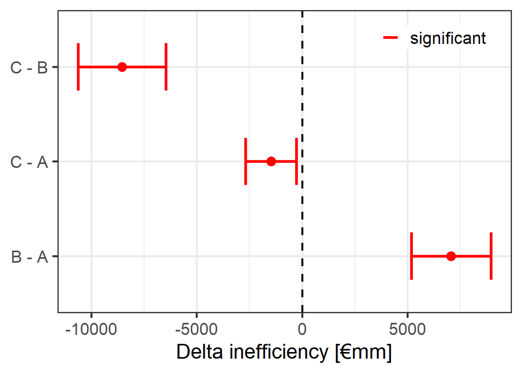

Figure 3: Post-Hoc results

```r
# Define mean, min, max and p for the plot
colnames(data.post.hoc)[4:7]<-c("mean",
                      "min",
                      "max",
                      "p")


# Create data frame for graphical depiction
data.post.hoc <- data.frame(id = c("B - A", "C - A", "C - B"),
                mean = data.post.hoc$mean,
                min = data.post.hoc$min,
                max = data.post.hoc$max,
                idt = ifelse(data.post.hoc$p < 0.05,
                           "significant",
                           "not significant")
                )

# Plot post-hoc results - if significant red, otherwise green color
ggplot(data.post.hoc, aes(id, color = idt)) +
  geom_point(aes(x = id, y = mean), size = 4, show.legend = F) +
  scale_y_continuous(breaks = pretty_breaks(n = 10)) +
  geom_errorbar(aes(ymin = min,
                    ymax = max),
                width = 0.5,
                size = 1.25) +
  labs(x = NULL, color = NULL) +
  scale_color_manual(values = c("red","green")) +
  scale_y_continuous("Delta inefficiency [€mm]", breaks = pretty_breaks(n = 5)) +
  coord_flip() +
  theme_bw(base_size = 20) +
  geom_hline(yintercept = 0, linetype = "dashed", color = "black", size = 1) +
  theme(
    legend.title = element_blank(),
    legend.position = c(.95, 0.95),
    legend.justification = c("right", "top"),
    legend.box.just = "right",
    legend.margin = margin(3, 3, 3, 3)
    )
```

# **Eta-squared (effect size)**

Due to eta-squared the area of cutted bars has the biggest influence on the (in)efficiency of cutting discs! But the disc type and circumferential speed of the cutting machine has also an - albeit a small - effect on (in)efficiency.

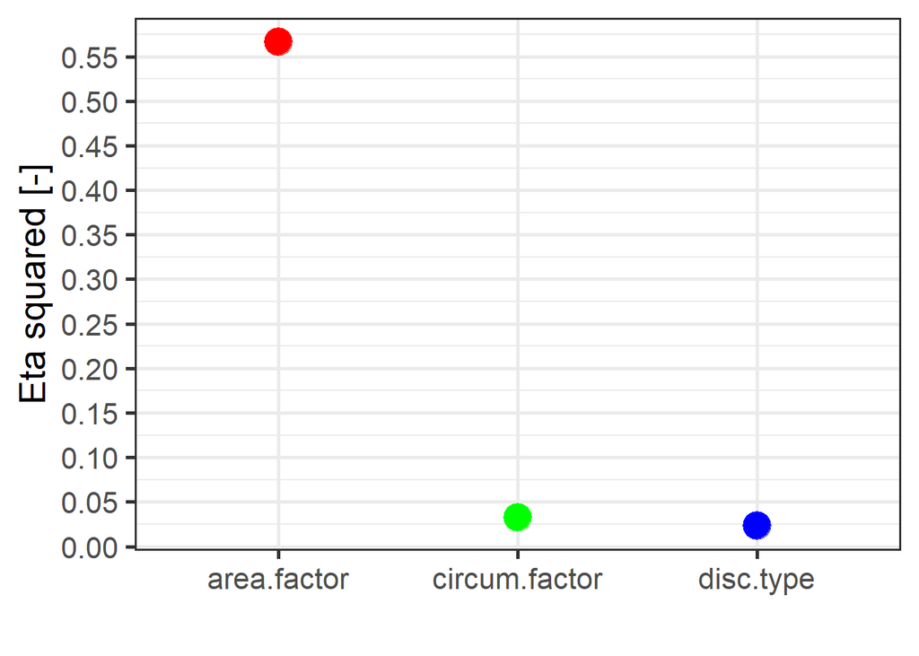

Figure 4: Eta squared